# Assignment_2

# Visualize images that demonstrate when x-rays demonstrate Covid Positivity and when they do not (You can present visuals of each category in the data if you would like to.).

```
WARNING:matplotlib.image:Clipping input data to the valid range for imshow with RGB data ([0..1] for floats or [0..255] for integers).
WARNING:matplotlib.image:Clipping input data to the valid range for imshow with RGB data ([0..1] for floats or [0..255] for integers).
WARNING:matplotlib.image:Clipping input data to the valid range for imshow with RGB data ([0..1] for floats or [0..255] for integers).
```

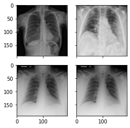

```python
import matplotlib.pyplot as plt
from mpl_toolkits.axes_grid1 import ImageGrid
import numpy as np
import random

im1 =preprocessor(fnames[0][0])
im2 =preprocessor(fnames[0][1])
im3 =preprocessor(fnames[1][1])
im4 =preprocessor(fnames[1][1])

fig = plt.figure(figsize=(4., 4.))
grid = ImageGrid(fig, 111,  # similar to subplot(111)
                 nrows_ncols=(2, 2),  # creates 2x2 grid of axes
                 axes_pad=0.25,  # pad between axes in inch.
                 )

for ax, im in zip(grid, [im1, im2, im3, im4]):
    # Iterating over the grid returns the Axes.
    ax.imshow(im)
plt.show()
```

# Discuss the dataset in general terms and describe why building a predictive model using this data might be practically useful. Who could benefit from a model like this? Explain.

### In general, this dataset contains COVID-19 radiography information, specifically showing X-rays demonstrating a person being COVID-positive and negative. By building a predictive model using COVID radiography data, this helps to streamline the COVID-19 diagnosis and treatment process. With a predictive model, this allows for early detection of COVID-19, accurate diagnosis as well as optimal resource allocation. As such, health care professionals would benefit the most from a model like this, streamlining the whole process for future patients and allowing for health care workers to provide treatment as soon as possible.

# Run at least three prediction models to try to predict x-ray images well. Use transfer learning for at least one of these models

# Submit your best three models to the leader board for the Covid X-ray Diagnostic AI Model Share competition.

```python
import tensorflow as tf
```

```python
! pip install aimodelshare --upgrade
# Restart session Runtime > Restart runtime
```

[output not shown]

[output cut: 9 more lines]

[output not shown]

```python
apiurl='https://bb4mkgq8sb.execute-api.us-east-2.amazonaws.com/prod/m'

import aimodelshare as ai
experiment= ai.Experiment(apiurl)

from aimodelshare.aws import set_credentials
set_credentials(apiurl=apiurl)
```

```
AI Modelshare Username:··········
AI Modelshare Password:··········
AI Model Share login credentials set successfully.
```

### Keras NN

```python
with tf.device('/device:GPU:0'): #"/GPU:0": Short-hand notation for the first GPU of your machine that is visible to TensorFlow.

  model = tf.keras.Sequential([
    tf.keras.layers.Conv2D(kernel_size=3, filters=32, padding='same', activation='relu', input_shape=(192, 192, 3)),
    tf.keras.layers.Conv2D(kernel_size=1, filters=32, padding='same', activation='relu'),
    tf.keras.layers.MaxPooling2D(pool_size=2),
    tf.keras.layers.Conv2D(kernel_size=3, filters=64, padding='same', activation='relu'),
    tf.keras.layers.Conv2D(kernel_size=1, filters=64, padding='same', activation='relu'),
    tf.keras.layers.MaxPooling2D(pool_size=2),
    tf.keras.layers.Conv2D(kernel_size=3, filters=128, padding='same', activation='relu'),
    tf.keras.layers.Conv2D(kernel_size=1, filters=128, padding='same', activation='relu'),
    tf.keras.layers.Flatten(),
    tf.keras.layers.Dense(3, activation='softmax')
  ])

  model.compile(
    optimizer="adam", # to use callback set lr arg such as Adam(lr=0.001) instead
    loss= 'categorical_crossentropy',
    metrics=['accuracy'])

  # Fitting the CNN to the Training set
  model.fit(X_train, y_train,
                    epochs = 1, verbose=1,validation_split=.2) #, callbacks=[red_lr]) for callback that automatically adjusts lr
```

[output not shown]

```python
model.save("model1.h5", save_format="h5")
```

```python
# Reload model and data
import tensorflow as tf
model = tf.keras.models.load_model('model1.h5',compile=False)
model.compile(
    optimizer="adam", # to use callback set lr arg such as Adam(lr=0.001) instead
    loss= 'categorical_crossentropy',
    metrics=['accuracy'])
model.summary()
```

```
Model: "sequential"
_________________________________________________________________
 Layer (type)                Output Shape              Param #
=================================================================
 conv2d (Conv2D)             (None, 192, 192, 32)      896

 conv2d_1 (Conv2D)           (None, 192, 192, 32)      1056

 max_pooling2d (MaxPooling2D  (None, 96, 96, 32)       0
 )

 conv2d_2 (Conv2D)           (None, 96, 96, 64)        18496

 conv2d_3 (Conv2D)           (None, 96, 96, 64)        4160

 max_pooling2d_1 (MaxPooling  (None, 48, 48, 64)       0
 2D)

 conv2d_4 (Conv2D)           (None, 48, 48, 128)       73856

 conv2d_5 (Conv2D)           (None, 48, 48, 128)       16512

 flatten (Flatten)           (None, 294912)            0

 dense (Dense)               (None, 3)                 884739

=================================================================
Total params: 999,715
Trainable params: 999,715
Non-trainable params: 0
_________________________________________________________________
```

```python
# Save preprocessor function (may need to reload function in cell above)
import aimodelshare as ai
ai.export_preprocessor(preprocessor,"")
```

```
Your preprocessor is now saved to 'preprocessor.zip'
```

```python
# Save tf.keras model (or any tensorflow model) to local ONNX file
from aimodelshare.aimsonnx import model_to_onnx

onnx_model = model_to_onnx(model, framework='keras',
                          transfer_learning=False,
                          deep_learning=True)

with open("model.onnx", "wb") as f:
    f.write(onnx_model.SerializeToString())
```

```
WARNING: AutoGraph could not transform <function trace_model_call.<locals>._wrapped_model at 0x7f8e0691c280> and will run it as-is.
Cause: Unable to locate the source code of <function trace_model_call.<locals>._wrapped_model at 0x7f8e0691c280>. Note that functions defined in certain environments, like the interactive Python shell, do not expose their source code. If that is the case, you should define them in a .py source file.…
To silence this warning, decorate the function with @tf.autograph.experimental.do_not_convert
```

```python
#Use X_test data to generate model predictions and make leaderboard submission

#Generate and save predictions

#Load preprocessed data
#If you run out of Colab memory restart runtime, reload data and try again
import pickle

# Open the file in binary mode
with open('X_test.pkl', 'rb') as file:
    # Call load method to deserialze
    X_test = pickle.load(file)

# Open the file in binary mode
with open('y_train.pkl', 'rb') as file:
    # Call load method to deserialze
    y_train = pickle.load(file)

prediction_column_index=model.predict(X_test).argmax(axis=1)

# extract correct prediction labels
prediction_labels = [y_train.columns[i] for i in prediction_column_index]
```

```
WARNING: AutoGraph could not transform <function Model.make_predict_function.<locals>.predict_function at 0x7f8d99cf2af0> and will run it as-is.
Please report this to the TensorFlow team. When filing the bug, set the verbosity to 10 (on Linux, `export AUTOGRAPH_VERBOSITY=10`) and attach the full output.
Cause: closure mismatch, requested ('self', 'step_function'), but source function had ()
To silence this warning, decorate the function with @tf.autograph.experimental.do_not_convert
```

```python
# Submit Model 1 to Competition Leaderboard
experiment.submit_model(model_filepath = "model.onnx",
                                 preprocessor_filepath="preprocessor.zip",
                                 prediction_submission=prediction_labels)
```

```
Insert search tags to help users find your model (optional):
Provide any useful notes about your model (optional):

Your model has been submitted as model version 261

To submit code used to create this model or to view current leaderboard navigate to Model Playground:

 https://www.modelshare.org/detail/model:3340
```

### Applying regularization to weights

```python
from tensorflow.keras import regularizers
```

```python
with tf.device('/device:GPU:0'): #"/GPU:0": Short-hand notation for the first GPU of your machine that is visible to TensorFlow.

  model2 = tf.keras.Sequential([
    tf.keras.layers.Conv2D(kernel_size=3, filters=32, padding='same', activation='relu', input_shape=(192, 192, 3), kernel_regularizer=regularizers.L1(l1=0.1)),
    tf.keras.layers.Conv2D(kernel_size=1, filters=32, padding='same', activation='relu', kernel_regularizer=regularizers.L1(l1=0.1)),
    tf.keras.layers.MaxPooling2D(pool_size=2),
    tf.keras.layers.Conv2D(kernel_size=3, filters=64, padding='same', activation='relu', kernel_regularizer=regularizers.L1(l1=0.1)),
    tf.keras.layers.Conv2D(kernel_size=1, filters=64, padding='same', activation='relu', kernel_regularizer=regularizers.L1(l1=0.1)),
    tf.keras.layers.MaxPooling2D(pool_size=2),
    tf.keras.layers.Conv2D(kernel_size=3, filters=128, padding='same', activation='relu', kernel_regularizer=regularizers.L1(l1=0.1)),
    tf.keras.layers.Conv2D(kernel_size=1, filters=128, padding='same', activation='relu', kernel_regularizer=regularizers.L1(l1=0.1)),
    tf.keras.layers.Flatten(),
    tf.keras.layers.Dense(3, activation='softmax')
  ])

  model2.compile(
    optimizer="adam", # to use callback set lr arg such as Adam(lr=0.001) instead
    loss= 'categorical_crossentropy',
    metrics=['accuracy'])

  # Fitting the CNN to the Training set
  model2.fit(X_train, y_train,
                    epochs = 1, verbose=1,validation_split=.2) #, callbacks=[red_lr]) for callback that automatically adjusts lr
```

[output not shown]

```python
model2.save("model2.h5", save_format="h5")
```

```python
# Reload model and data
import tensorflow as tf
model2 = tf.keras.models.load_model('model2.h5',compile=False)
model2.compile(
    optimizer="adam", # to use callback set lr arg such as Adam(lr=0.001) instead
    loss= 'categorical_crossentropy',
    metrics=['accuracy'])
model2.summary()
```

```
Model: "sequential_1"
_________________________________________________________________
 Layer (type)                Output Shape              Param #
=================================================================
 conv2d_6 (Conv2D)           (None, 192, 192, 32)      896

 conv2d_7 (Conv2D)           (None, 192, 192, 32)      1056

 max_pooling2d_2 (MaxPooling  (None, 96, 96, 32)       0
 2D)

 conv2d_8 (Conv2D)           (None, 96, 96, 64)        18496

 conv2d_9 (Conv2D)           (None, 96, 96, 64)        4160

 max_pooling2d_3 (MaxPooling  (None, 48, 48, 64)       0
 2D)

 conv2d_10 (Conv2D)          (None, 48, 48, 128)       73856

 conv2d_11 (Conv2D)          (None, 48, 48, 128)       16512

 flatten_1 (Flatten)         (None, 294912)            0

 dense_1 (Dense)             (None, 3)                 884739

=================================================================
Total params: 999,715
Trainable params: 999,715
Non-trainable params: 0
_________________________________________________________________
```

```python
# Save preprocessor function (may need to reload function in cell above)
import aimodelshare as ai
ai.export_preprocessor(preprocessor,"")
```

```
Your preprocessor is now saved to 'preprocessor.zip'
```

```python
# Save tf.keras model (or any tensorflow model) to local ONNX file
from aimodelshare.aimsonnx import model_to_onnx

onnx_model2 = model_to_onnx(model2, framework='keras',
                          transfer_learning=False,
                          deep_learning=True)

with open("model2.onnx", "wb") as f:
    f.write(onnx_model2.SerializeToString())
```

[output not shown]

```python
#Use X_test data to generate model predictions and make leaderboard submission

#Generate and save predictions

#Load preprocessed data
#If you run out of Colab memory restart runtime, reload data and try again
import pickle

# Open the file in binary mode
with open('X_test.pkl', 'rb') as file:
    # Call load method to deserialze
    X_test = pickle.load(file)

# Open the file in binary mode
with open('y_train.pkl', 'rb') as file:
    # Call load method to deserialze
    y_train = pickle.load(file)

prediction_column_index=model2.predict(X_test).argmax(axis=1)

# extract correct prediction labels
prediction_labels = [y_train.columns[i] for i in prediction_column_index]
```

```
WARNING: AutoGraph could not transform <function Model.make_predict_function.<locals>.predict_function at 0x7f8cdc76c5e0> and will run it as-is.
Please report this to the TensorFlow team. When filing the bug, set the verbosity to 10 (on Linux, `export AUTOGRAPH_VERBOSITY=10`) and attach the full output.
Cause: closure mismatch, requested ('self', 'step_function'), but source function had ()
To silence this warning, decorate the function with @tf.autograph.experimental.do_not_convert
```

```python
# Submit Model 2 to Competition Leaderboard
experiment.submit_model(model_filepath = "model2.onnx",
                                 preprocessor_filepath="preprocessor.zip",
                                 prediction_submission=prediction_labels)
```

```
Insert search tags to help users find your model (optional):
Provide any useful notes about your model (optional):

Your model has been submitted as model version 262

To submit code used to create this model or to view current leaderboard navigate to Model Playground:

 https://www.modelshare.org/detail/model:3340
```

### Transfer Learning with Resnet

```python
# example of loading a version of the Resnet Model
from tensorflow.keras.applications import ResNet50
from tensorflow.keras.models import Sequential,Model
from tensorflow.keras.preprocessing import image
from tensorflow.keras.models import Model
from tensorflow.keras.layers import Dense, GlobalAveragePooling2D, Flatten
from tensorflow.keras import backend as K


# load model new input layer shape.

IMG_SHAPE = (192, 192, 3)

# Create base model
base_model = ResNet50(input_shape=IMG_SHAPE, include_top=False, weights='imagenet')

base_model.summary() # Notice unfrozen number of trainable parameters
```

```
Downloading data from https://storage.googleapis.com/tensorflow/keras-applications/resnet/resnet50_weights_tf_dim_ordering_tf_kernels_notop.h5
Model: "resnet50"
__________________________________________________________________________________________________
 Layer (type)                   Output Shape         Param #     Connected to
==================================================================================================
 input_1 (InputLayer)           [(None, 192, 192, 3  0           []
                                )]

 conv1_pad (ZeroPadding2D)      (None, 198, 198, 3)  0           ['input_1[0][0]']

 conv1_conv (Conv2D)            (None, 96, 96, 64)   9472        ['conv1_pad[0][0]']

 conv1_bn (BatchNormalization)  (None, 96, 96, 64)   256         ['conv1_conv[0][0]']

 conv1_relu (Activation)        (None, 96, 96, 64)   0           ['conv1_bn[0][0]']

 pool1_pad (ZeroPadding2D)      (None, 98, 98, 64)   0           ['conv1_relu[0][0]']

 pool1_pool (MaxPooling2D)      (None, 48, 48, 64)   0           ['pool1_pad[0][0]']

 conv2_block1_1_conv (Conv2D)   (None, 48, 48, 64)   4160        ['pool1_pool[0][0]']

 conv2_block1_1_bn (BatchNormal  (None, 48, 48, 64)  256         ['conv2_block1_1_conv[0][0]']
 ization)

 conv2_block1_1_relu (Activatio  (None, 48, 48, 64)  0           ['conv2_block1_1_bn[0][0]']
 n)

 conv2_block1_2_conv (Conv2D)   (None, 48, 48, 64)   36928       ['conv2_block1_1_relu[0][0]']

 conv2_block1_2_bn (BatchNormal  (None, 48, 48, 64)  256         ['conv2_block1_2_conv[0][0]']
 ization)

 conv2_block1_2_relu (Activatio  (None, 48, 48, 64)  0           ['conv2_block1_2_bn[0][0]']
 n)

 conv2_block1_0_conv (Conv2D)   (None, 48, 48, 256)  16640       ['pool1_pool[0][0]']

 conv2_block1_3_conv (Conv2D)   (None, 48, 48, 256)  16640       ['conv2_block1_2_relu[0][0]']

```

[output cut: 419 more lines]

```
 conv5_block3_3_conv (Conv2D)   (None, 6, 6, 2048)   1050624     ['conv5_block3_2_relu[0][0]']

 conv5_block3_3_bn (BatchNormal  (None, 6, 6, 2048)  8192        ['conv5_block3_3_conv[0][0]']
 ization)

 conv5_block3_add (Add)         (None, 6, 6, 2048)   0           ['conv5_block2_out[0][0]',
                                                                  'conv5_block3_3_bn[0][0]']

 conv5_block3_out (Activation)  (None, 6, 6, 2048)   0           ['conv5_block3_add[0][0]']

==================================================================================================
Total params: 23,587,712
Trainable params: 23,534,592
Non-trainable params: 53,120
__________________________________________________________________________________________________
```

```python
# Next step: Freeze the weights of the model so that they are not trained with you fit the model
# setting the entire model's trainable flag to False will freeze all the layers.

base_model.trainable = False

base_model.summary() # Note the trainable parameters at the bottom now equal zero.
```

```
Model: "resnet50"
__________________________________________________________________________________________________
 Layer (type)                   Output Shape         Param #     Connected to
==================================================================================================
 input_1 (InputLayer)           [(None, 192, 192, 3  0           []
                                )]

 conv1_pad (ZeroPadding2D)      (None, 198, 198, 3)  0           ['input_1[0][0]']

 conv1_conv (Conv2D)            (None, 96, 96, 64)   9472        ['conv1_pad[0][0]']

 conv1_bn (BatchNormalization)  (None, 96, 96, 64)   256         ['conv1_conv[0][0]']

 conv1_relu (Activation)        (None, 96, 96, 64)   0           ['conv1_bn[0][0]']

 pool1_pad (ZeroPadding2D)      (None, 98, 98, 64)   0           ['conv1_relu[0][0]']

 pool1_pool (MaxPooling2D)      (None, 48, 48, 64)   0           ['pool1_pad[0][0]']

 conv2_block1_1_conv (Conv2D)   (None, 48, 48, 64)   4160        ['pool1_pool[0][0]']

 conv2_block1_1_bn (BatchNormal  (None, 48, 48, 64)  256         ['conv2_block1_1_conv[0][0]']
 ization)

 conv2_block1_1_relu (Activatio  (None, 48, 48, 64)  0           ['conv2_block1_1_bn[0][0]']
 n)

 conv2_block1_2_conv (Conv2D)   (None, 48, 48, 64)   36928       ['conv2_block1_1_relu[0][0]']

 conv2_block1_2_bn (BatchNormal  (None, 48, 48, 64)  256         ['conv2_block1_2_conv[0][0]']
 ization)

 conv2_block1_2_relu (Activatio  (None, 48, 48, 64)  0           ['conv2_block1_2_bn[0][0]']
 n)

 conv2_block1_0_conv (Conv2D)   (None, 48, 48, 256)  16640       ['pool1_pool[0][0]']

 conv2_block1_3_conv (Conv2D)   (None, 48, 48, 256)  16640       ['conv2_block1_2_relu[0][0]']

 conv2_block1_0_bn (BatchNormal  (None, 48, 48, 256)  1024       ['conv2_block1_0_conv[0][0]']
```

[output cut: 418 more lines]

```
 conv5_block3_3_conv (Conv2D)   (None, 6, 6, 2048)   1050624     ['conv5_block3_2_relu[0][0]']

 conv5_block3_3_bn (BatchNormal  (None, 6, 6, 2048)  8192        ['conv5_block3_3_conv[0][0]']
 ization)

 conv5_block3_add (Add)         (None, 6, 6, 2048)   0           ['conv5_block2_out[0][0]',
                                                                  'conv5_block3_3_bn[0][0]']

 conv5_block3_out (Activation)  (None, 6, 6, 2048)   0           ['conv5_block3_add[0][0]']

==================================================================================================
Total params: 23,587,712
Trainable params: 0
Non-trainable params: 23,587,712
__________________________________________________________________________________________________
```

```python
# Add new GAP layer and output layer to frozen layers of original model with adjusted input

# Create new classifier layers (and plug into output of last layer from above model using "model.layers[-1].output")
gap1 = GlobalAveragePooling2D()(base_model.layers[-1].output)
output = Dense(3, activation='softmax')(gap1)
# define new model
model3 = Model(inputs=base_model.inputs, outputs=output)
# summarize
model3.summary()
```

```
Model: "model"
__________________________________________________________________________________________________
 Layer (type)                   Output Shape         Param #     Connected to
==================================================================================================
 input_1 (InputLayer)           [(None, 192, 192, 3  0           []
                                )]

 conv1_pad (ZeroPadding2D)      (None, 198, 198, 3)  0           ['input_1[0][0]']

 conv1_conv (Conv2D)            (None, 96, 96, 64)   9472        ['conv1_pad[0][0]']

 conv1_bn (BatchNormalization)  (None, 96, 96, 64)   256         ['conv1_conv[0][0]']

 conv1_relu (Activation)        (None, 96, 96, 64)   0           ['conv1_bn[0][0]']

 pool1_pad (ZeroPadding2D)      (None, 98, 98, 64)   0           ['conv1_relu[0][0]']

 pool1_pool (MaxPooling2D)      (None, 48, 48, 64)   0           ['pool1_pad[0][0]']

 conv2_block1_1_conv (Conv2D)   (None, 48, 48, 64)   4160        ['pool1_pool[0][0]']

 conv2_block1_1_bn (BatchNormal  (None, 48, 48, 64)  256         ['conv2_block1_1_conv[0][0]']
 ization)

 conv2_block1_1_relu (Activatio  (None, 48, 48, 64)  0           ['conv2_block1_1_bn[0][0]']
 n)

 conv2_block1_2_conv (Conv2D)   (None, 48, 48, 64)   36928       ['conv2_block1_1_relu[0][0]']

 conv2_block1_2_bn (BatchNormal  (None, 48, 48, 64)  256         ['conv2_block1_2_conv[0][0]']
 ization)

 conv2_block1_2_relu (Activatio  (None, 48, 48, 64)  0           ['conv2_block1_2_bn[0][0]']
 n)

 conv2_block1_0_conv (Conv2D)   (None, 48, 48, 256)  16640       ['pool1_pool[0][0]']

 conv2_block1_3_conv (Conv2D)   (None, 48, 48, 256)  16640       ['conv2_block1_2_relu[0][0]']

 conv2_block1_0_bn (BatchNormal  (None, 48, 48, 256)  1024       ['conv2_block1_0_conv[0][0]']
```

[output cut: 424 more lines]

```
                                                                  'conv5_block3_3_bn[0][0]']

 conv5_block3_out (Activation)  (None, 6, 6, 2048)   0           ['conv5_block3_add[0][0]']

 global_average_pooling2d (Glob  (None, 2048)        0           ['conv5_block3_out[0][0]']
 alAveragePooling2D)

 dense_2 (Dense)                (None, 3)            6147        ['global_average_pooling2d[0][0]'
                                                                 ]

==================================================================================================
Total params: 23,593,859
Trainable params: 6,147
Non-trainable params: 23,587,712
__________________________________________________________________________________________________
```

```python
# Fit Resnet model with frozen imagenet weights and new input/output layer shapes (outputs have trainable parameters)

with tf.device('/device:GPU:0'): #"/GPU:0": Short-hand notation for the first GPU of your machine that is visible to TensorFlow.

  model3.compile(loss='categorical_crossentropy', optimizer='sgd', metrics=['acc'])

  model3.fit(X_train, y_train,
          epochs = 3, verbose=1,validation_split=.2)
```

[output not shown]

```python
# Save tf.keras model (or any tensorflow model) to local ONNX file
from aimodelshare.aimsonnx import model_to_onnx

onnx_model3 = model_to_onnx(model3, framework='keras',
                          transfer_learning=True,
                          deep_learning=True)

with open("model3.onnx", "wb") as f:
    f.write(onnx_model3.SerializeToString())
```

```
WARNING: AutoGraph could not transform <function trace_model_call.<locals>._wrapped_model at 0x7f8d140be700> and will run it as-is.
Cause: Unable to locate the source code of <function trace_model_call.<locals>._wrapped_model at 0x7f8d140be700>. Note that functions defined in certain environments, like the interactive Python shell, do not expose their source code. If that is the case, you should define them in a .py source file.…
To silence this warning, decorate the function with @tf.autograph.experimental.do_not_convert
```

```python
#Use X_test data to generate model predictions and make leaderboard submission

#Generate and save predictions

#Load preprocessed data
#If you run out of Colab memory restart runtime, reload data and try again
import pickle

# Open the file in binary mode
with open('X_test.pkl', 'rb') as file:
    # Call load method to deserialze
    X_test = pickle.load(file)

# Open the file in binary mode
with open('y_train.pkl', 'rb') as file:
    # Call load method to deserialze
    y_train = pickle.load(file)

prediction_column_index=model3.predict(X_test).argmax(axis=1)

# extract correct prediction labels
prediction_labels = [y_train.columns[i] for i in prediction_column_index]
```

```
WARNING: AutoGraph could not transform <function Model.make_predict_function.<locals>.predict_function at 0x7f8cd9381940> and will run it as-is.
Please report this to the TensorFlow team. When filing the bug, set the verbosity to 10 (on Linux, `export AUTOGRAPH_VERBOSITY=10`) and attach the full output.
Cause: closure mismatch, requested ('self', 'step_function'), but source function had ()
To silence this warning, decorate the function with @tf.autograph.experimental.do_not_convert
```

```python
# Submit Model 3 to Competition Leaderboard
experiment.submit_model(model_filepath = "model3.onnx",
                                 preprocessor_filepath="preprocessor.zip",
                                 prediction_submission=prediction_labels)
```

```
Insert search tags to help users find your model (optional):
Provide any useful notes about your model (optional):

Your model has been submitted as model version 263

To submit code used to create this model or to view current leaderboard navigate to Model Playground:

 https://www.modelshare.org/detail/model:3340
```